# Generalized Linear Model

Dr. Liu Qizhang

5 October 2016

In the previous lessons, you learned how to use linear regression to predict values of dependent variable, which is normally distributed. However, in real life, there are lots of cases that the dependent variable is either not continous or not normally distributed. For example, you may want to predict whether a customer is more likely to buy your product, or a bank may want to classify its customers into three categories: low risk, medium risk, or high risk. Sometimes you may want to predict number of occurance of certain event given specific data. Linear regression model will not work anymore for such scenarios.

Fortunately, under a framework named *Generalised Linear Models*, there are a wide range of methods developed to handle cases beyond the capability of linear regression. In R, *glm()* is the function designed to construct generalised linear model. The basic format of the function is

*glm(formula, family=family(link=function), data=)*

where *family* refers to the probability distribution and *function* is the function applied for this probability distribution in the model. The following table lists the default functions for a list of probability distributions covered by *glm()*.

| Family | Default link function |
| --- | --- |
| binomial | (link = “logit”) |
| gaussian | (link = “identity”) |
| gamma | (link = “inverse”) |
| inverse.gaussian | (link = “1/mu^2”) |
| poisson | (link = “log”) |
| quasi | (link = “identity”, variance = “constant”) |
| quasibinomial | (link = “logit”) |
| quasipoisson | (link = “log”) |

In this lesson, we will cover the most commonly used generalised linear models: Logistic Regression.

# Logistic Regression

Logisitc regression is used to predict a Yes/No binary outcome from a set of continuous variables or categorical variables. Let’s use a marketing case to illustrate the application of logistic regression.

```r
triers<-read.csv("Lasagna Triers.csv")
triers$Person <- NULL

#Have an overview of data
summary(triers)
```

```
##       Age            Weight          Income           PayType
##  Min.   :22.00   Min.   :142.0   Min.   :  2600   Hourly  :375
##  1st Qu.:31.00   1st Qu.:174.0   1st Qu.: 24475   Salaried:481
##  Median :37.50   Median :190.0   Median : 39950
##  Mean   :38.78   Mean   :192.7   Mean   : 45267
##  3rd Qu.:46.00   3rd Qu.:210.0   3rd Qu.: 58225
##  Max.   :64.00   Max.   :258.0   Max.   :190500
##     CarValue         CCDebt        Gender    LiveAlone DwellType
##  Min.   :  130   Min.   :   0   Female:398   No :711   Apt  :213
##  1st Qu.: 2110   1st Qu.: 560   Male  :458   Yes:145   Condo:239
##  Median : 4175   Median :1020                          Home :404
##  Mean   : 5908   Mean   :1431
##  3rd Qu.: 7718   3rd Qu.:1972
##  Max.   :33870   Max.   :8960
##    MallTrips         Nbhd     HaveTried
##  Min.   : 0.000   East :277   No :361
##  1st Qu.: 3.000   South:207   Yes:495
##  Median : 4.000   West :372
##  Mean   : 4.735
##  3rd Qu.: 7.000
##  Max.   :17.000
```

```r
## set the seed to make your partition reproductible
set.seed(123)
sample <- sample(c(TRUE,FALSE),nrow(triers),prob = c(0.75,0.25),replace = TRUE)

triers.train <- triers[sample, ]
triers.test <- triers[!sample, ]
```

We normally need to take a look at the relation between individual variables with the expected binary outcome to understand the impact of them on the outcome. It will not only help us understand the data better, but also build up a bottomline case for our prediction model.

Let’s start with continuous variable. The following plot shows how age affects people’s choice.

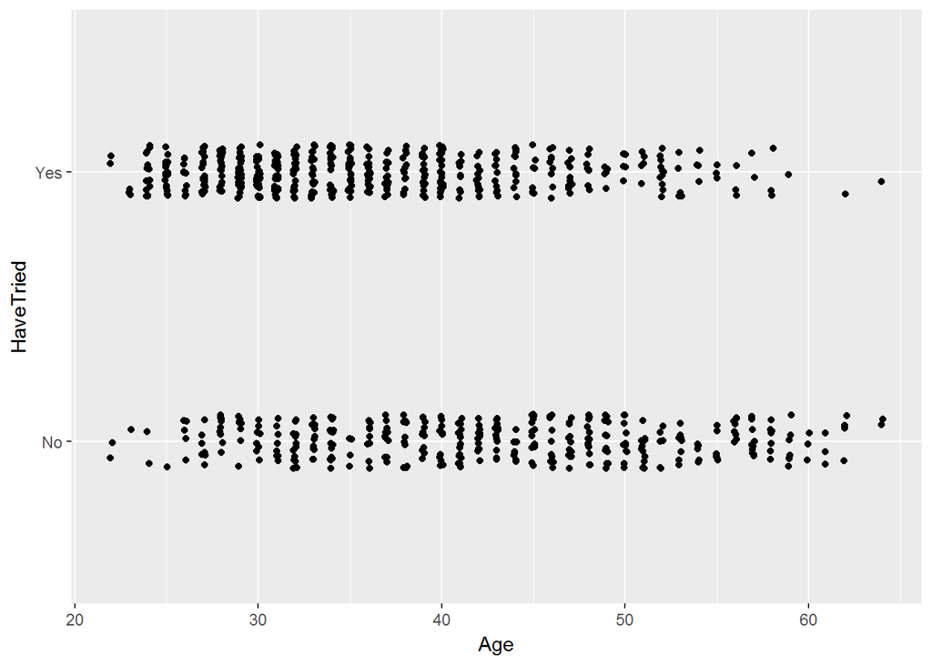

```r
library(ggplot2)
ggplot(triers,aes(x=Age,y=HaveTried)) +geom_point(position=position_jitter(width=0.1,height = 0.1))
```

Although it is not very clear, we may observer that younger people tend to say “Yes” to the product than older ones. So if we tried a naive method by simply predicting the outcome by Age (for example, predict those with age below 30 as “Yes” group and those with age above 30 as “No” group), then what will be the prediction error? The following codes give a visualization to answer this question.

```r
#We define a generic function that can be re-used to calculate error rate when predicting binary outcome by cutting a continuous independent variable.
PredictErrorByCutContinousVar <- function(threshold, data, predictor, outcome){
    predict <- factor(data[,predictor] < threshold, levels=c("FALSE","TRUE"))
    table <- table(predict = predict, actual = data[,outcome])
    table
    return ((table[1,2]+table[2,1])/sum(table))
}

#find the rage of age
range(triers$Age)
```

```
## [1] 22 64
```

```r
ages<-21:64
errors <- sapply(ages,PredictErrorByCutContinousVar,triers,"Age","HaveTried")
df <- data.frame(Age=ages,Error=errors)
df
```

```
##    Age     Error
## 1   21 0.5782710
## 2   22 0.5782710
## 3   23 0.5782710
## 4   24 0.5759346
## 5   25 0.5630841
## 6   26 0.5408879
## 7   27 0.5350467
## 8   28 0.5163551
## 9   29 0.5023364
## 10  30 0.4684579
## 11  31 0.4450935
## 12  32 0.4193925
## 13  33 0.4100467
## 14  34 0.3995327
```

[output cut: 30 more lines]

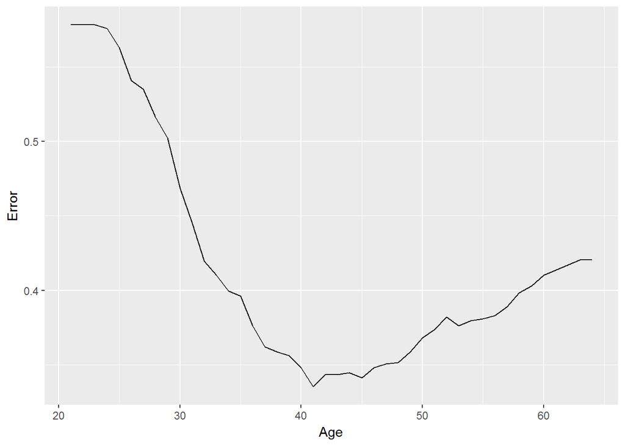

```r
ggplot(df, aes(x=Age,y=Error)) + geom_line()
```

It shows that if we use 41 as the cut-off age to divide customers into two groups, the prediction error 0.335 is lowest possible error. You can apply the same technique to check other continuous variables.

Next, that’s look at categorical variables. How about PayType? Can it be a good factor to predict people’s choice? The following codes answer the question.

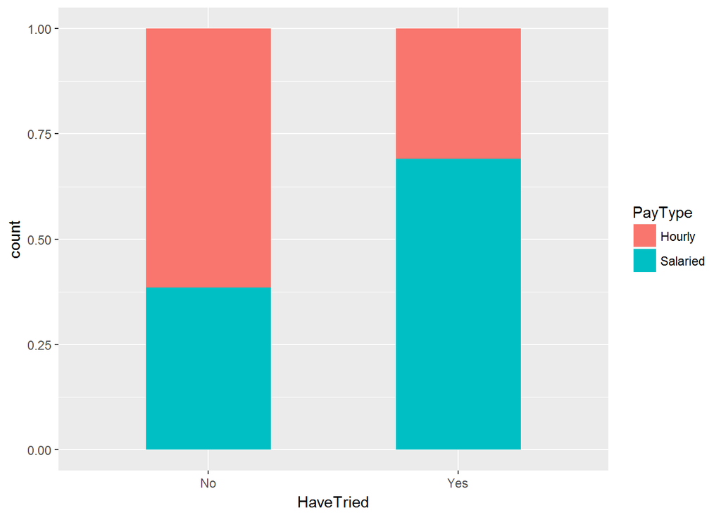

```r
ggplot(triers,aes(x=HaveTried,fill=PayType)) + geom_bar(position="fill", width = 0.5)
```

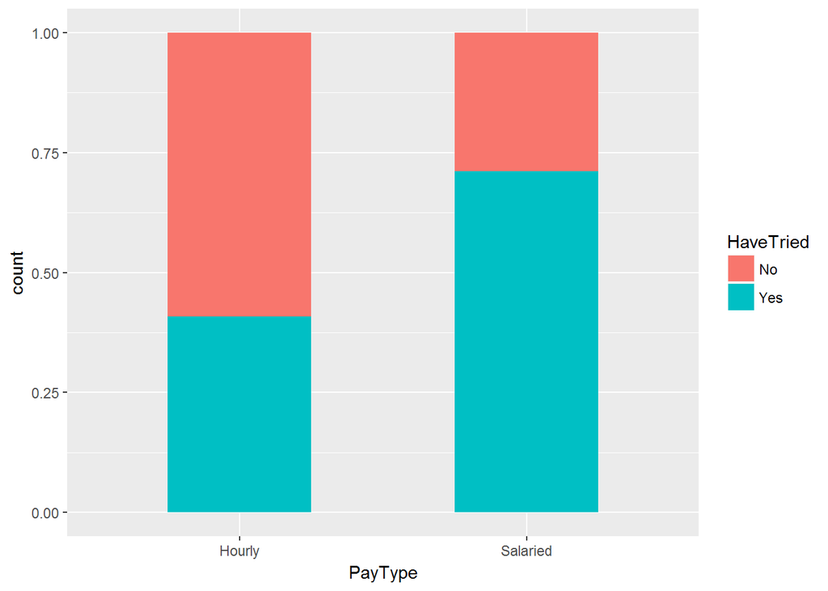

```r
ggplot(triers,aes(x=PayType,fill=HaveTried)) + geom_bar(position="fill", width = 0.5)
```

Both charts show that salaried customers have higher chances to be triers of the new product. So if we use a naive method to simply classify salaried customers as triers, what is the error rate?

```r
table <- table(triers$PayType == "Salaried", triers$HaveTried)
table
```

```
##
##          No Yes
##   FALSE 222 153
##   TRUE  139 342
```

```r
error <- (table[1,2]+table[2,1])/sum(table)
error
```

```
## [1] 0.3411215
```

The error rate is about 0.34. You may try other categorical variables.

In general, we can conclude that a naive method by simply classifying customers by one of the independent variable will give us an error rate of around 33%. Our logstic regression model cannot perform worse than this.

Now let’s try the most trivial logistic regression by including all independent variables.

```r
fit.full <- glm(HaveTried ~ ., data=triers.train, family=binomial())

summary(fit.full)
```

```
##
## Call:
## glm(formula = HaveTried ~ ., family = binomial(), data = triers.train)
##
## Deviance Residuals:
##     Min       1Q   Median       3Q      Max
## -2.5634  -0.4852   0.1346   0.4859   2.3495
##
## Coefficients:
##                   Estimate Std. Error z value Pr(>|z|)
## (Intercept)     -2.811e+00  1.131e+00  -2.486 0.012912 *
## Age             -6.435e-02  1.329e-02  -4.841 1.29e-06 ***
## Weight           1.828e-03  4.819e-03   0.379 0.704454
## Income           7.219e-06  4.911e-06   1.470 0.141596
## PayTypeSalaried  1.479e+00  2.765e-01   5.347 8.95e-08 ***
## CarValue        -2.126e-05  2.704e-05  -0.786 0.431680
## CCDebt           1.584e-04  1.244e-04   1.274 0.202827
## GenderMale       4.120e-01  2.401e-01   1.716 0.086140 .
## LiveAloneYes     1.174e+00  3.425e-01   3.426 0.000612 ***
## DwellTypeCondo  -2.571e-01  3.465e-01  -0.742 0.458233
## DwellTypeHome    1.029e-01  3.044e-01   0.338 0.735422
## MallTrips        6.615e-01  7.249e-02   9.125  < 2e-16 ***
## NbhdSouth        7.265e-01  3.051e-01   2.381 0.017270 *
## NbhdWest         2.114e+00  2.873e-01   7.359 1.85e-13 ***
## ---
## Signif. codes:  0 '***' 0.001 '**' 0.01 '*' 0.05 '.' 0.1 ' ' 1
##
## (Dispersion parameter for binomial family taken to be 1)
##
##     Null deviance: 870.02  on 645  degrees of freedom
## Residual deviance: 453.39  on 632  degrees of freedom
## AIC: 481.39
##
## Number of Fisher Scoring iterations: 6
```

From the summary, we found that weight, income, CarValue, CCDebt, and DwellType may not make a significant contribution to the trying of the lasagna. We may try to simplify the model by discarding them in the model.

```r
fit.simplified <- glm(HaveTried ~ Age  + PayType  + Gender +
                    LiveAlone  + MallTrips + Nbhd, data=triers.train, family=binomial())

summary(fit.simplified)
```

```
##
## Call:
## glm(formula = HaveTried ~ Age + PayType + Gender + LiveAlone +
##     MallTrips + Nbhd, family = binomial(), data = triers.train)
##
## Deviance Residuals:
##     Min       1Q   Median       3Q      Max
## -2.6229  -0.5043   0.1386   0.5090   2.3494
##
## Coefficients:
##                 Estimate Std. Error z value Pr(>|z|)
## (Intercept)     -2.27862    0.65445  -3.482 0.000498 ***
## Age             -0.06205    0.01312  -4.729 2.26e-06 ***
## PayTypeSalaried  1.43274    0.24278   5.901 3.61e-09 ***
## GenderMale       0.41234    0.23744   1.737 0.082458 .
## LiveAloneYes     1.16004    0.33224   3.492 0.000480 ***
## MallTrips        0.69610    0.06697  10.395  < 2e-16 ***
## NbhdSouth        0.70399    0.29963   2.350 0.018796 *
## NbhdWest         2.09535    0.28389   7.381 1.57e-13 ***
## ---
## Signif. codes:  0 '***' 0.001 '**' 0.01 '*' 0.05 '.' 0.1 ' ' 1
##
## (Dispersion parameter for binomial family taken to be 1)
##
##     Null deviance: 870.02  on 645  degrees of freedom
## Residual deviance: 458.89  on 638  degrees of freedom
## AIC: 474.89
##
## Number of Fisher Scoring iterations: 6
```

The simplified model has an AIC close to the full model. Since the two models are nested, we can use *anova()* function to compare them.

```r
anova(fit.simplified,fit.full,test="Chisq")
```

```
## Analysis of Deviance Table
##
## Model 1: HaveTried ~ Age + PayType + Gender + LiveAlone + MallTrips +
##     Nbhd
## Model 2: HaveTried ~ Age + Weight + Income + PayType + CarValue + CCDebt +
##     Gender + LiveAlone + DwellType + MallTrips + Nbhd
##   Resid. Df Resid. Dev Df Deviance Pr(>Chi)
## 1       638     458.89
## 2       632     453.39  6   5.5022   0.4812
```

## Prediction Accuracy

Let’s see the result of the model:

```r
triers.train$pred <- predict(fit.simplified,newdata = triers.train,type="response")
triers.train$pred
```

[output not shown]

[output cut: 115 more lines]

```r
triers.test$pred <- predict(fit.simplified,newdata = triers.test,type="response")
```

Note the additional parameter *type=“response”*. This tells the predict() function to return the predicted probabilities *y*. If you don’t specify this parameter and use the default parameter, then *predict()* will return the output of the *link* function, which is *logit(y)*.

Our goal is to be able to classify customers into two groups: possible triers of lasagna and no triers. So we expect the model to give us high probability for positive instances and low probability for negative instances. We can check the result graphically by plotting the distribution of predicted probabilities for both positive instances and negative instances.

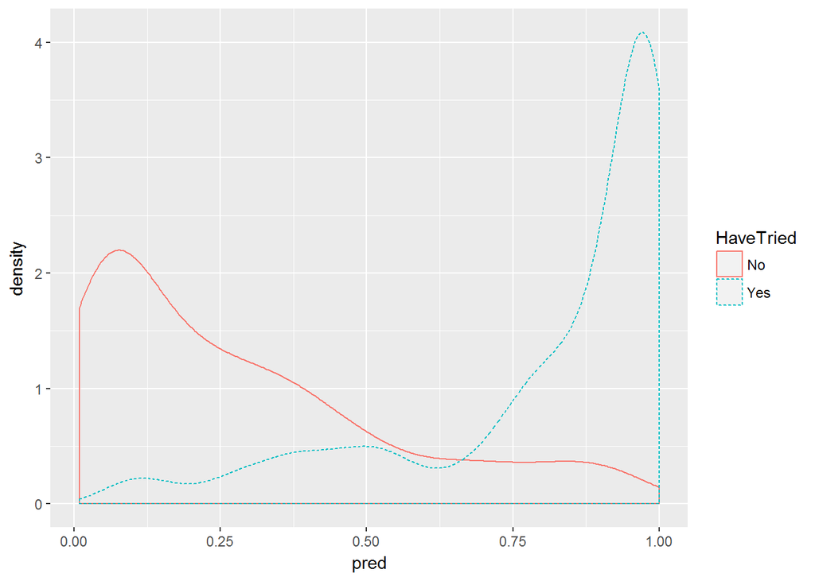

```r
library(ggplot2)
ggplot(triers.train, aes(x=pred, color=HaveTried,linetype=HaveTried)) + geom_density()
```

The following codes provides two plots to compare the effect of threshold on precision and recall:

```r
library(ROCR)
```

[figure not shown]

```r
library(grid)
library(ggplot2)

triers.train$outcome <- predict(fit.simplified,newdata = triers.train,type="response")
predObj <- prediction(triers.train$outcome,triers.train$HaveTried)
precObj <- performance(predObj, measure="prec")
recObj <- performance(predObj,measure="rec")

precision <- (precObj@y.values)[[1]]
prec.x<-(precObj@x.values)[[1]]
recall <- (recObj@y.values)[[1]]

rocFrame <- data.frame(threshold=prec.x, precision=precision,recall=recall)

nplot<-function(plist){
     n<-length(plist)
     grid.newpage()
     pushViewport(viewport(layout = grid.layout(n,1)))
     vplayout=function(x,y) {viewport(layout.pos.row = x,layout.pos.col = y)}
     for(i in 1:n){
         print(plist[[i]],vp=vplayout(i,1))
     }
}

pnull <- mean(as.numeric(levels(triers.train$HaveTried)[triers.train$HaveTried]))     #percentage of triers in the training set
pl<-ggplot(rocFrame,aes(x=threshold))+geom_line(aes(y=precision/pnull)) + coord_cartesian(xlim=c(0,1),ylim=c(0,2))
p2<-ggplot(rocFrame,aes(x=threshold))+geom_line(aes(y=recall)) + coord_cartesian(xlim=c(0,1),ylim=c(0,1))

nplot(list(pl,p2))
```

The above codes use built-in functions from *ROCR* package. It is indeed not difficult to write our own codes to plot the graph. The following codes should help you understand the logic better.

```r
#This function is to check errorrate of a model with a given threshold
ErrorRate <- function(threshold, model, data, field) {
    probs <- predict(model,newdata=data,type="response")
    outcomes <- factor(probs > threshold, levels=c("FALSE","TRUE"))
    table <- table(outcomes,data[,field])
    print(table)
    return((table[1,2]+table[2,1])/sum(table))
}

#This function is to plot the errorrate against different threshold
PlotErrorRateByThreshold<-function(model,data,field) {
    require(ggplot2)
    thresholds<-seq(0,1,0.01)
    errors <- sapply(thresholds,ErrorRate,model,data,field)
    df <- data.frame(Threshold=thresholds, Error.Rate = errors)
    ggplot(df,aes(x=Threshold,y=Error.Rate)) + geom_line()
}

#precision is a function to find the precision of a logistics model with a given threshold
#precision is the fraction of the predicted positives are true positives
precision <- function(threshold,model, data, field){
  response <- predict(model,newdata = data,type="response")
  prediction <- ifelse(response>threshold,"Yes","No")
  num.predicted.postive <- sum(prediction == "Yes")
  num.correct.positive <- sum(prediction == "Yes" & prediction == data[,field])
  return (num.correct.positive/num.predicted.postive)
}

#recall is a function to find the recall of a logisitc model with a given threshold
#recall is the fraction of the true positives the classifier finds
recall <- function(threshold,model, data, field){
  response <- predict(model,newdata = data,type="response")
  prediction <- ifelse(response>threshold,"Yes","No")
  num.predicted.postive <- sum(prediction == "Yes" & prediction == data[,field])
  num.true.positive <- sum(data[,field] == "Yes")
  return (num.predicted.postive/num.true.positive)
}

#This function is to plot precision and recall against thresholds
plotPrecisionVSRecall <- function(model, data, field){
  require(ggplot2)
  thresholds <- seq(0,1,by=0.01)
  precisions <- sapply(thresholds,precision,model,data,field)
  recalls <- sapply(thresholds,recall,model,data,field)
  df <- data.frame(Threshold=thresholds,Precision=precisions,Recall=recalls)
  library(reshape2)
  df1<-melt(df,id.vars="Threshold",variable.name="Type")
  ggplot(data = df1,aes(x=Threshold, y=value, color=Type,lty = Type)) + geom_line()
}
```

Now, let’s use 0.5 as a threshold and apply the model on the test data.

```r
ctab.test <- table(pred=triers.test$pred > 0.5, triers=triers.test$HaveTried)
ctab.test
```

```
##        triers
## pred    No Yes
##   FALSE 81  12
##   TRUE  21  96
```

```r
precision <- ctab.test[2,2]/sum(ctab.test[2,])
precision
```

```
## [1] 0.8205128
```

```r
recall <- ctab.test[2,2]/sum(ctab.test[,2])
recall
```

```
## [1] 0.8888889
```

```r
enrich<-precision/(mean(as.numeric(triers.test$HaveTried))-1)
enrich
```

```
## [1] 1.595442
```

We see pretty good outcome,which is quite consistent with the result in training set.

## Interpretation of coefficients

It is more tricky to interpret the coefficients in logistic regression model than in linear regression model. Let’s use the case to explain.

```r
coefficients(fit.simplified)
```

```
##     (Intercept)             Age PayTypeSalaried      GenderMale
##     -2.27861821     -0.06205365      1.43274425      0.41234146
##    LiveAloneYes       MallTrips       NbhdSouth        NbhdWest
##      1.16004319      0.69609910      0.70399314      2.09535035
```

The coefficient for age is negative, indicating that the older customer has lower likelihood to be the triers. You can try to interpret the coefficient in the similar way as above.

## Visulise effect of individual factors

In this section, let’s try to visualise the effect of individual factors on the prediction.

```r
AgeModel <- glm(HaveTried ~ Age, data=triers.train, family=binomial())
range(triers.train$Age)  #To find the range of age
```

```
## [1] 22 64
```

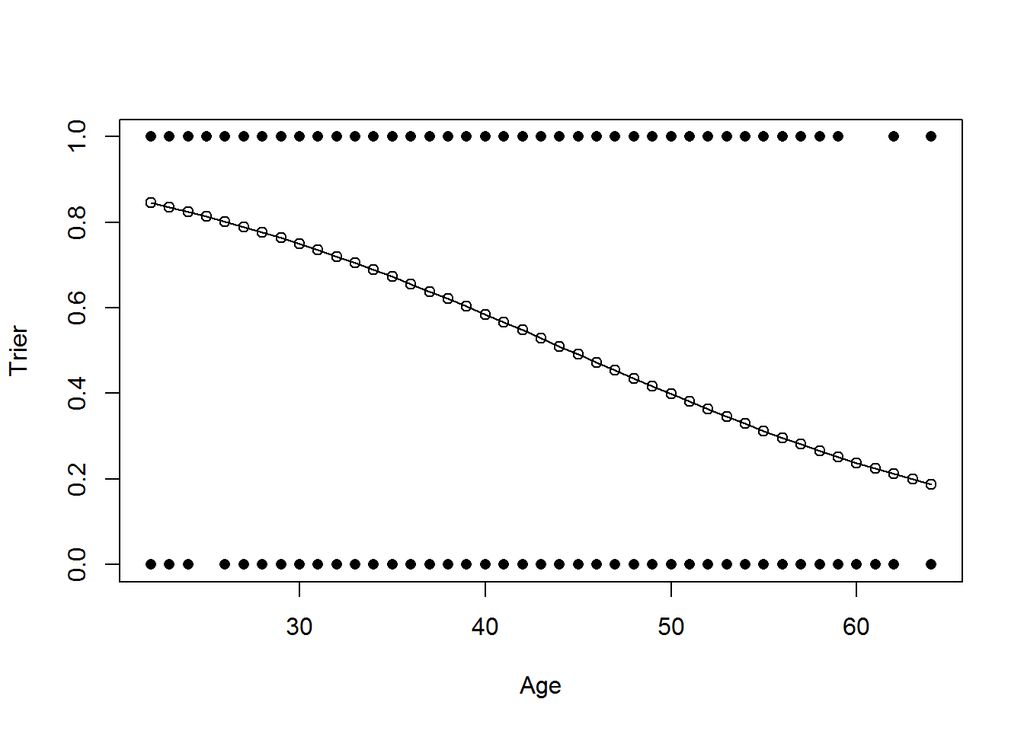

```r
age.x <- seq(22, 64, 1)
age.y <- predict(AgeModel, list(Age = age.x),type="response")

levels(triers.train$HaveTried) = c(0,1)

plot(triers.train$Age, as.numeric(levels(triers.train$HaveTried)[triers.train$HaveTried]), pch = 16, xlab = "Age", ylab = "Trier")
lines(x=age.x, y=age.y, color="Red")
points(x=age.x, y=age.y, color="Red")
```

As you can see, older a customer is, less likely he will try the product.

# Evaluating Models by ROC

In previous section, i illustrated how to compare thresholds by looking at precision and recall. In machine learning, a more common method is to check ROC curve. Please refer to http://web.ydu.edu.tw/~alan9956/docu/refer/roc_introduction.pdf for an introduction of ROC.

*ROCR* package also provides function for us to plot ROCR curve. Please refer to https://hopstat.wordpress.com/2014/12/19/a-small-introduction-to-the-rocr-package/ for a short tutorial on how to use it.

Similar to precision and recall case, we can also write our own function to plot ROC curve. The following codes illustrate the concepts.

```r
#TPR is a function to calculate true positive rate
TPR <- function(threshold,model, data, field){
  response <- predict(model,newdata = data,type="response")
  prediction <- ifelse(response>threshold,"Yes","No")
  TP <- sum(prediction == "Yes" & prediction == data[,field])
  P <- sum(data[,field] == "Yes")
  return (TP/P)
}

#FPR is a function to calculate false positive rate
FPR <- function(threshold,model, data, field){
  response <- predict(model,newdata = data,type="response")
  prediction <- ifelse(response>threshold,"Yes","No")
  FP <- sum(prediction == "Yes" & prediction != data[,field])
  N <- sum(data[,field] == "No")
  return (FP/N)
}

#This function is to plot the famous precision-recall curve.
plotROCCurve <- function(model, data, field){
    require(ggplot2)
  thresholds <- seq(0,1,by=0.01)
  TPRs <- sapply(thresholds,TPR,model,data,field)
  FPRs <- sapply(thresholds,FPR,model,data,field)
  df <- data.frame(Threshold=thresholds,TPR=TPRs,FPR=FPRs)
  ggplot(data = df,aes(x=FPR, y=TPR)) + geom_line()
}

#This function is to plot the famous precision-recall curve.
plotPrecisionRecallCurve <- function(model, data, field){
    require(ggplot2)
  thresholds <- seq(0,1,by=0.01)
  precisions <- sapply(thresholds,precision,model,data,field)
  recalls <- sapply(thresholds,recall,model,data,field)
  df <- data.frame(Threshold=thresholds,Precision=precisions,Recall=recalls)
  ggplot(data = df,aes(x=Recall, y=Precision)) + geom_line()
}
```

plotROCCruve plots ROC curve. I also added Precision-Recall curve for you to compare with. Both curves can be used to compare classification models. You may search online to find relevant articles regarding this.